# DATASCI 385 - Experimental Methods

Lecture 22 - Survey Experiments for Sensitive Topics

Danilo Freire

danilo.freire@emory.edu

Department of Data and Decision Sciences  
Emory University

# Hello, everyone! 😉

# Notes about the group project

## Group project presentations

- The simulated datasets have been sent to you by email
- Please check if the data are complete and let me know if you have any issues
  - It’s possible that I did not include some variables that you need. Please let me know 😉
- You will have about 15 minutes to present your project, with 5 minutes for questions
- The order of the presentations has also been randomised:
- Wednesday, December 03:
- Caffeine consumption and cognitive performance: Max, Sherelle, Ari, and William
- Causal Alignment Prompting: Mingke, Nicole, Anny, and Zixuan
- Effect of Monitoring on Perfomance: Lucy, Francisco, Gina, Bert, Tiger, and Toni
- Music and Vocabulary: Peter, Oscar, Sarah, and Vera
- Monday, December 08:
- Sleep and Stress: Rola, Sissi, Chrissy, and Selena
- AI and Assessment Scores: Tammy, Rami, Tiffany, Tashfia, and Aadit
- Framing Effects and Student Choices: Katie, Yoonsuh, Krishang, and Vidhant

# Brief recap 📚

## Survey experiments

### Core components

- Survey experiments combine random assignment with survey methods to study attitudes
- Main applications: behavioural economics, psychology, marketing, political behaviour, and public opinion
- Core design variations:
  - Presence/absence of stimuli
  - Dosage levels of treatment intensity
  - Qualitative variations in treatment content
- Validation methods:
  - Manipulation checks post-treatment
  - Placebo treatments for specificity testing
  - Non-equivalent outcomes for effect containment
- Common implementations:
  - Question wording manipulations
  - Vignette designs with randomised attributes
  - Audio or video stimuli

# Today’s plan 📅

## Survey experiments with a twist

- What to do when subjects have an incentive to lie?
- Sensitive topics are often difficult to study
- Social desirability bias is a common problem in survey research
- We need special techniques to study these problems
- List experiments, randomised response technique, endorsement experiments, and conjoint experiments are possible solutions
- Maintains plausible deniability for respondents
- Software to estimate these models: http://sensitivequestions.org/
- List experiments measure prevalence indirectly through item counts
- Randomised response techniques use probability models for anonymity
- Endorsement experiments assess support without direct attribution
- Conjoint analysis measures preferences through trade-off scenarios
- Sometimes requires careful probability weighting in analysis

# List experiments 📋

## What is a list experiment?

- The logic of list experiments is simple
- Respondents are presented with a list of items and asked how many they agree with
  - Just how many items, not which ones
- The list includes a sensitive item (e.g., “I have committed a crime”) and several non-sensitive items
- The sensitive item is randomly assigned to a subset of respondents
- The key is to compare the average number of items agreed with between the treatment group (who sees the sensitive item) and the control group (who does not)
- The difference in means provides an estimate of the prevalence of the sensitive item
- This method is also known as the item count technique

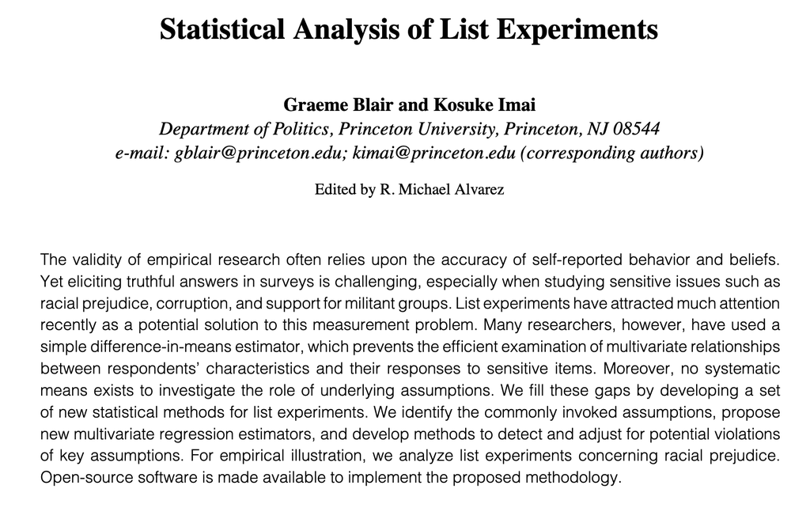

Source: [Blair and Imai (2012)](https://imai.fas.harvard.edu/research/files/listP.pdf)

## Example

### Measuring prejudice

> Now I’m going to read you three things that sometimes make people angry or upset. After I read all three, just tell me HOW MANY of them upset you. (I don’t want to know which ones, just how many.)
> 1. the federal government increasing the tax on gasoline
> 2. professional athletes getting million-dollar-plus salaries
> 3. large corporations polluting the environment

> How many, if any, of these things upset you?

## Example of a list experiment

### Measuring prejudice

> Now I’m going to read you four things that sometimes make people angry or upset. After I read all four, just tell me HOW MANY of them upset you. (I don’t want to know which ones, just how many.)
> 1. the federal government increasing the tax on gasoline
> 2. professional athletes getting million-dollar-plus salaries
> 3. large corporations polluting the environment
> 4. **a black family moving next door to you**

> How many, if any, of these things upset you?

## Some notation

- Sample of respondents $N$, where $T_i = 1$ if respondent $i$ is in the treatment group and $T_i = 0$ if in the control group
- $J$ is the number of items in the control list, $J + 1$ is the number of items in the treatment list
- $Z_{ij}(t)$ a binary variable denoting respondent $i$’s preference for the $j$th control item for $j = 1, \dots , J$ under the treatment status $t = 0, 1$
- $Y_{i}(0) = \sum_{j=1}^{J} Z_{ij}(0)$ is the potential answer $i$ would give if asked about the control list
- $Y_{i}(1) = \sum_{j=1}^{J+1} Z_{ij}(1)$ is the number of items in the treatment list that respondent $i$ agrees with
- The observed response is $Y_i = Y_i(T_i)$, where $Y_i(0)$ is in the range of $\{0,1, \dots, J\}$ and $Y_i(1)$ is in the range of $\{0,1, \dots J + 1\}$
- Now let’s discuss the assumptions…

## Assumptions

### No design effects

- First, we need to assume that the addition of the sensitive item does not change the sum of affirmative answers to the control items
- It is not necessary that respondents answer the control items truthfully, but the average number of affirmative answers must be the same in both groups
- This is the no design effects assumption
- Formally, for each respondent $i = 1, \dots, N$, we assume:

$$\sum_{j=1}^{J} Z_{ij}(0) = \sum_{j=1}^{J} Z_{ij}(1)$$

### No liars

- Second, we need to assume that the sensitive item is not a lie
- That is, all respondents give truthful answers for the sensitive item
- This is a strong assumption, as you can imagine

$$Z_{i,J+1}(1) = Z^*_{i,J+1}$$

where $Z^*_{i,J+1}$ represents a truthful answer to the sensitive item. The treatment effect is

$$\hat{\tau} = \frac{1}{N_1} \sum_{i=1}^{N} T_i Y_i - \frac{1}{N_0} \sum_{i=1}^{N} (1 - T_i) Y_i,$$

where $N_1 = \sum_{i=1}^{N} T_i$ is the size of the treatment group and $N_0 = N - N_1$ is the size of the control group

## More about list experiments

### Notes about the design

- List experiments have several advantages, as they are easy to implement and clear to respondents
- But they have some issues as well:
  - Limited power to detect small effects
  - Floor effects: If many respondents disagree with all or most items, it is hard to estimate the prevalence of the sensitive item
  - Ceiling effects: If someone agrees with all items, we know for sure they agree with the sensitive item
  - Sample homogeneity: If the sample is too homogeneous, it may be hard to detect differences
- But there are some solutions for these problems
- Use items that contradict each other to reduce ceiling and floor effects
  - Example: ask about pro-gun and pro-choice items
- A weakly informative Bayesian prior and covariates can also be used to reduce ceiling and floor effects
- You can also add direct questions to the experiment and use a weighted average of the direct question estimate and the list experiment estimate among those who answer “No” to the direct question ([Arrow et al. 2015](https://doi.org/10.1093/jssam/smu023))
- You can also include multiple sensitive items in the list experiment
- The main issue is to interpret the results correctly, so we usually see what explains one sensitive item in the list experiment

- Let’s revisit the previous example:

> Now I’m going to read you four things that sometimes make people angry or upset. After I read all four, just tell me HOW MANY of them upset you. (I don’t want to know which ones, just how many.)
> 1. the federal government increasing the tax on gasoline
> 2. professional athletes getting million-dollar-plus salaries
> 3. large corporations polluting the environment
> 4. **a black family moving next door to you**

> How many, if any, of these things upset you?

## R example

- More information at https://list.sensitivequestions.org/articles/getting-started.html

```r
library(list)
data(race)

lm.results <- ictreg(y ~ 1, data = race, treat = "treat", J=3, method = "lm")
summary(lm.results)
```

```
Item Count Technique Regression

Call: ictreg(formula = y ~ 1, data = race, treat = "treat", J = 3,
    method = "lm")

Sensitive item
              Est.    S.E.
(Intercept) 0.0678 0.04962

Control items
               Est.    S.E.
(Intercept) 2.13413 0.03317

Residual standard error: 0.866365 with 1211 degrees of freedom

Number of control items J set to 3. Treatment groups were indicated by '' and '' and the control group by ''.
```

## R example

- More information at https://list.sensitivequestions.org/articles/getting-started.html

```r
library(list)
data(race)

lm.results <- ictreg(y ~ south + age + male + college, data = race,
                  treat = "treat", J=3, method = "lm")
summary(lm.results)
```

```
Item Count Technique Regression

Call: ictreg(formula = y ~ south + age + male + college, data = race,
    treat = "treat", J = 3, method = "lm")

Sensitive item
                Est.    S.E.
(Intercept) -0.43430 0.16033
south        0.20198 0.11760
age          0.07309 0.03051
male         0.18023 0.09846
college      0.11446 0.09775

Control items
                Est.    S.E.
(Intercept)  2.40606 0.10511
south       -0.18021 0.07450
age          0.02047 0.01998
male        -0.20177 0.06522
college     -0.39408 0.06406

Residual standard error: 0.837231 with 1203 degrees of freedom

Number of control items J set to 3. Treatment groups were indicated by '' and '' and the control group by ''.
```

# Did hidden Trump voters exist?

## Did hidden Trump voters exist?

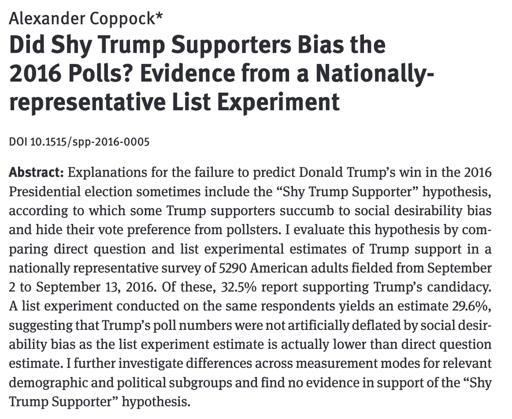

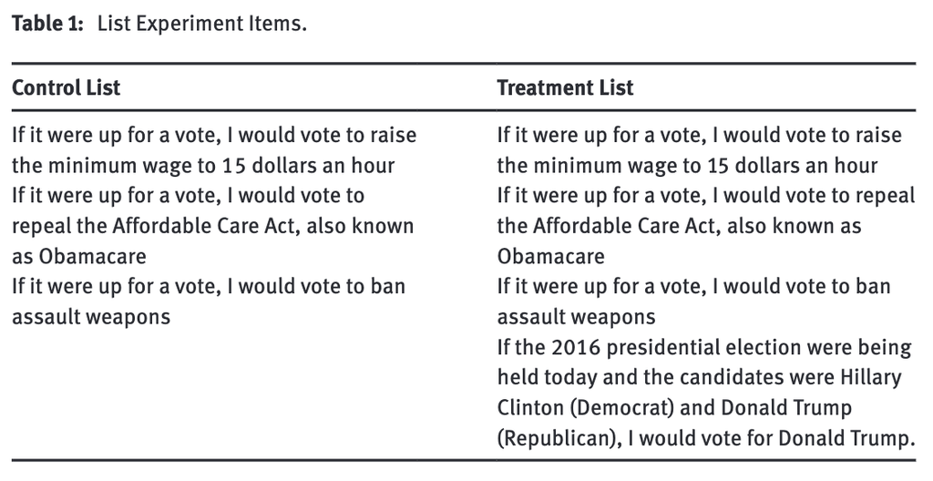

Source: [Coppock (2017)](https://alexandercoppock.com/coppock_2017a.pdf)

## Did hidden Trump voters exist?

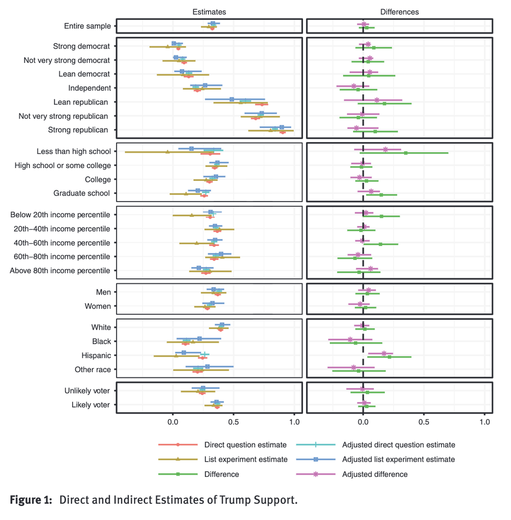

# Do Russians support the war in Ukraine?

## Do Russians support the war in Ukraine?

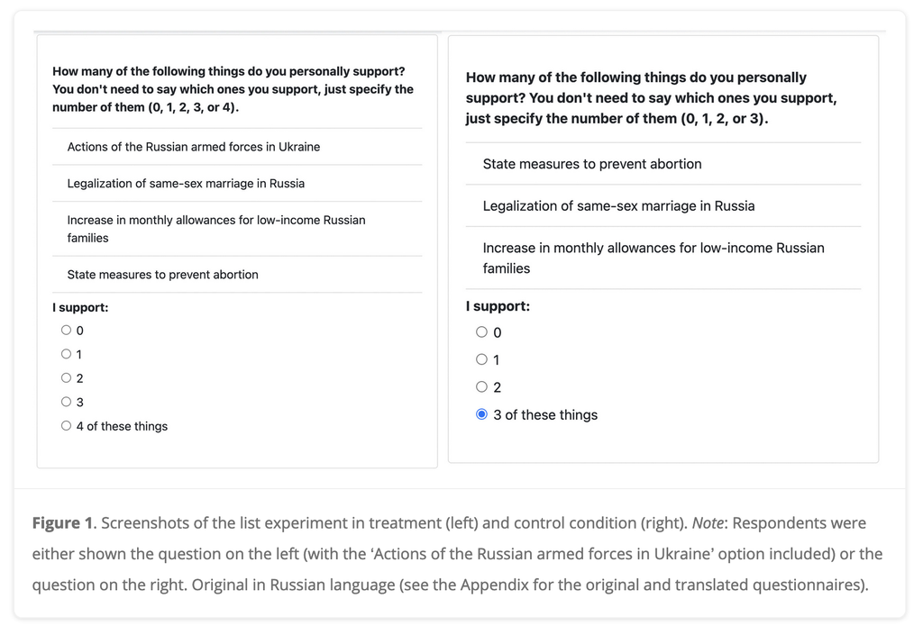

Source: [Chapovski (2022)](https://journals.sagepub.com/doi/full/10.1177/20531680221108328)

## Do Russians support the war in Ukraine?

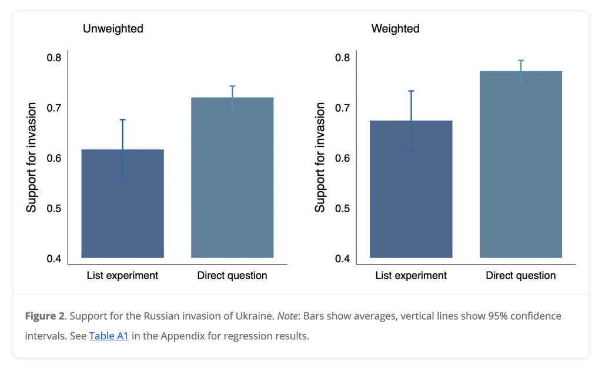

## Do Russians support the war in Ukraine?

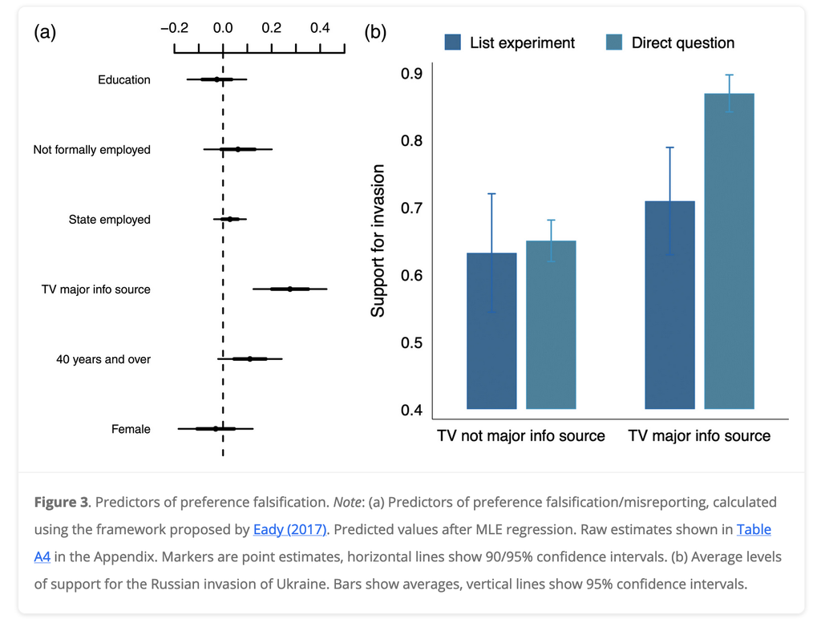

# Endorsement experiments

## What is an endorsement experiment?

- Endorsement experiments are a type of survey experiment that measure support for a policy or candidate
- They are a variation of the vignette experiment, where respondents are presented with a scenario and asked to evaluate it
- Here, the scenario includes an endorsement from a prominent figure or group
- These experiments are often used to study partisan bias, group identity, or framing effects
- The main advantage of endorsement experiments is that they can elicit preferences without directly asking about them
- While it is easy to estimate them when there is one group involved, it is more difficult when there are multiple groups
- It is a little hard to combine the items, but it is possible
- A solution is to use Bayesian hierarchical models, which is described in this (very technical) paper: [Bullock et al (2011)](https://imai.fas.harvard.edu/research/files/support.pdf)
- We can also use conjoint experiments, as we’ll see in a bit!

## Example

### Measuring Support for Militant Groups in Pakistan

- Militant violence in Pakistan is a serious international problem, yet little is known about who supports militant organisations and why
- There is a strong incentive for locals to falsify information to avoid repercussions
- Also, asking respondents directly poses safety risks for researchers and participants alike
- Unlike a direct measure, non-response and social desirability biases are minimised since respondents are reacting to the policy and not directly to the group itself (or so it seems! 😅)
- The authors asked respondents about their level of support for polio vaccinations, curriculum reforms, crime regulations, and border disputes
- Control group:

```
The World Health Organization recently announced
a plan to introduce universal polio vaccination
across Pakistan. How much do you support
such a plan?
(1) A great deal; (2) A lot; (3) A moderate amount;
(4) A little; (5) Not at all.
```

- Treatment group:

```
The World Health Organization recently announced
a plan to introduce universal polio vaccination
across Pakistan. **Pakistani militant groups
fighting in Kashmir have voiced support for
this program.** How much do you support such a plan?
(1) A great deal; (2) A lot; (3) A moderate amount;
(4) A little; (5) Not at all.
```

## Results

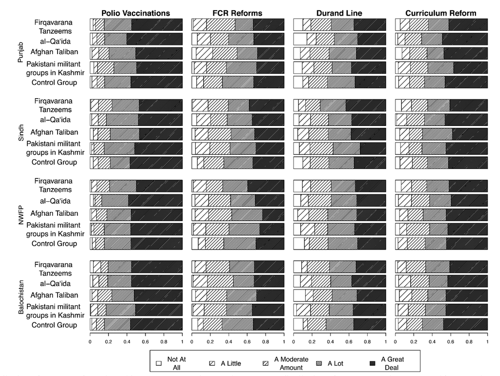

# Did political endorsement influence mass opinion during COVID-19?

## Did political endorsement influence mass opinion during COVID-19?

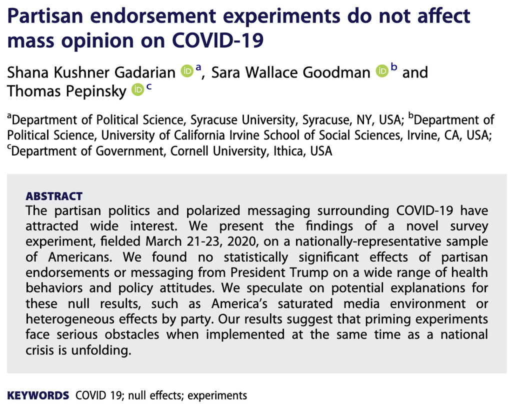

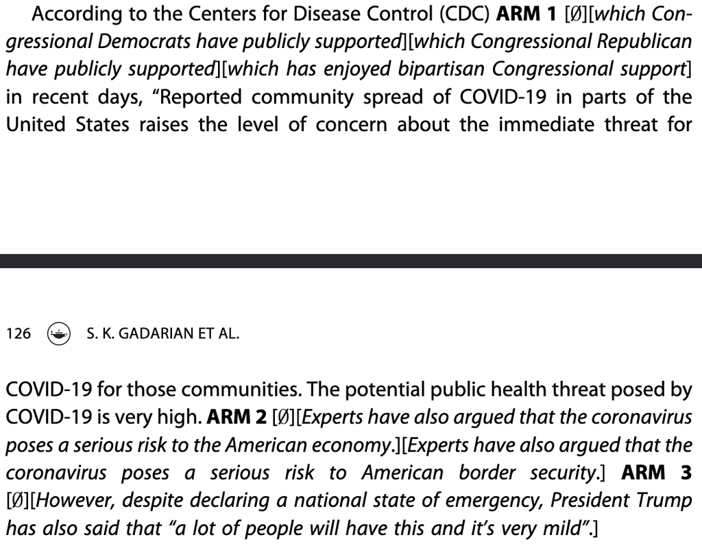

Source: [Gadarian et al (2021)](https://doi.org/10.1080/17457289.2021.1924727)

## Did political endorsement influence mass opinion during COVID-19?

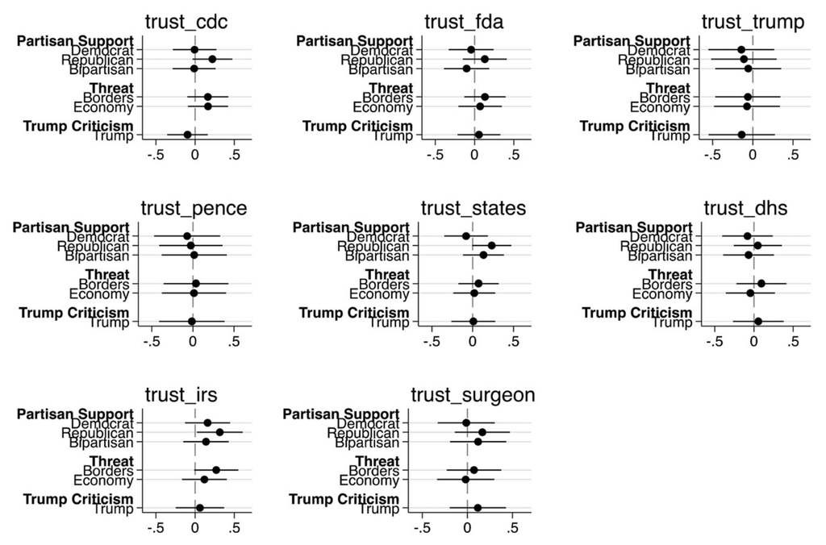

## Did political endorsement influence mass opinion during COVID-19?

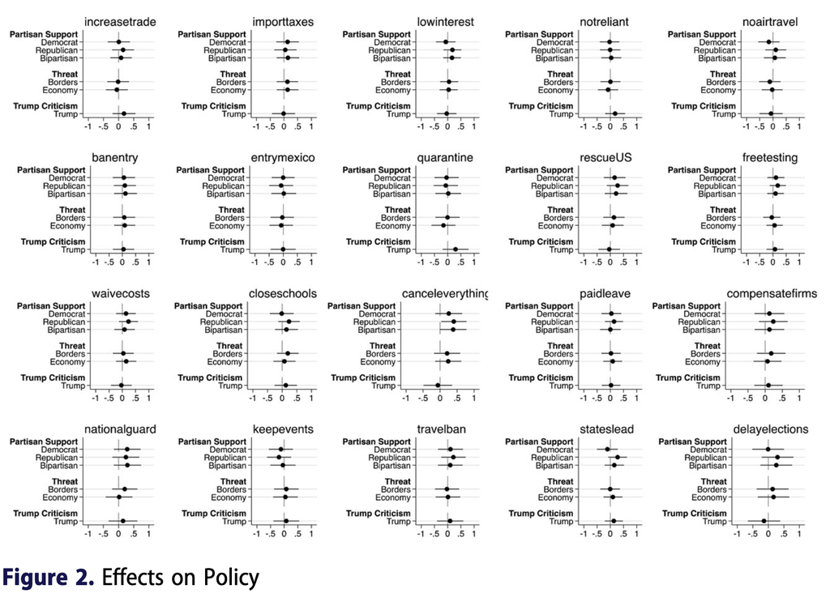

# Randomised response techniques 🎲

## Randomised response

- This is an old technique (Werner 1965, Boruch 1971) that is used to reduce social desirability bias
- The main idea is the following:
  - The respondent rolls a die or other randomising device out of view of the enumerator
  - The enumerator does not know the outcome of the randomisation
  - For instance, if a 1 shows on the die, the respondent says no
  - If a 6 shows, the respondent says yes
  - If any other number shows, the respondent answers truthfully
  - The enumerator sees the answer, but does not know if it is true or random
- The method works because the probabilities are known so we can estimate the true proportion of respondents who agree with the sensitive item
- However, the method is a little confusing to respondents and it is important to either run the experiment in person or provide clear instructions if running it online
- Believe it or not, this is the most effective method to reduce social desirability bias!

## Xenophobia and antisemitism in Germany

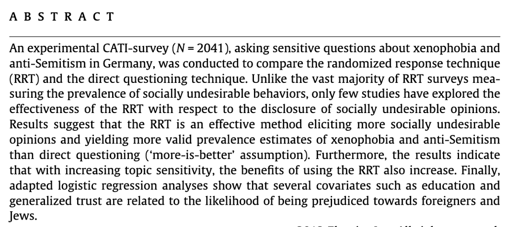

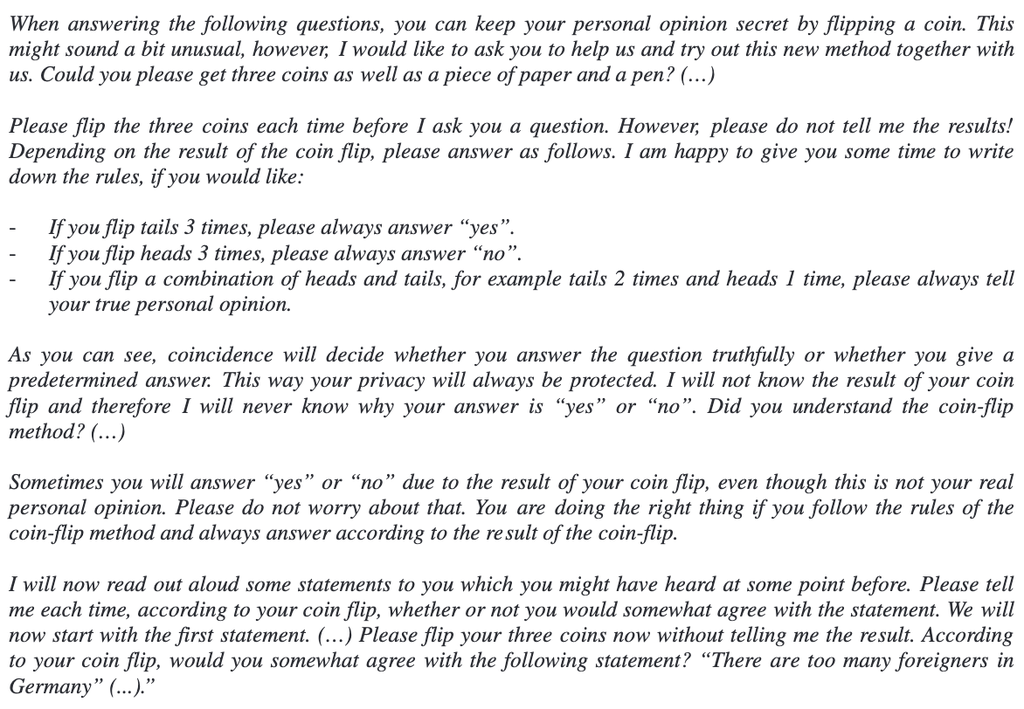

Source: [Krumpal (2012)](https://www.sciencedirect.com/science/article/abs/pii/S0049089X12001172)

## Xenophobia and antisemitism in Germany

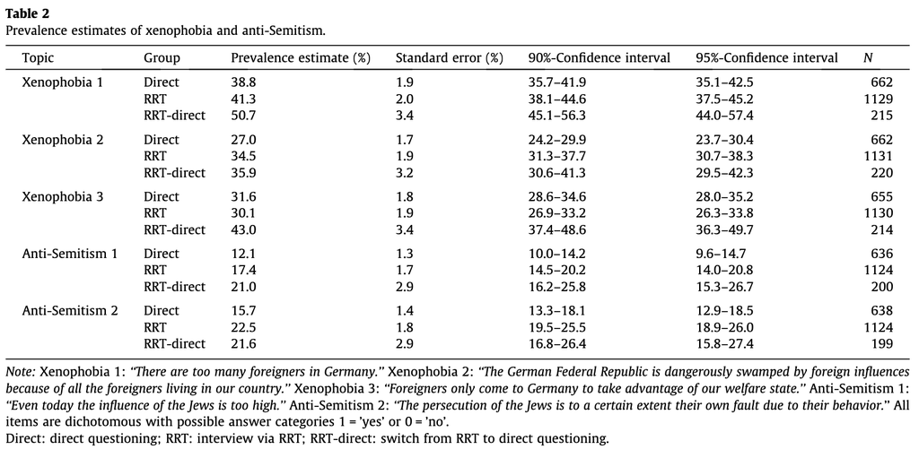

# Conjoint analysis

## Conjoint experiments

- Conjoint analysis measures preferences for multiple attributes of a product, service, or policy
- The method aims to understand how different factors influence decision-making
- It is also used to study trade-offs between different attributes
- As with the other experiments we discussed, conjoint analysis provides plausible deniability for respondents
- Why is that? Because respondents are not asked about their preferences directly
- Instead, they are presented with a series of hypothetical scenarios and asked to choose their preferred option
- The main advantage of conjoint analysis is that it allows researchers to study complex preferences in a more realistic way
- Another advantage is that the method is very robust, flexible, and adaptable to various research contexts
- It also increases sample size significantly as respondents are presented with several scenarios
- However, it can be time-consuming to design and analyse, but that’s pretty much the only con 😉
- Ah, software to implement it is quite difficult to use as well!
- See [my own experiment](https://github.com/danilofreire/lynching-experiment-brazil) for an example (we will discuss it in the next lecture!)

## Hainmueller et al (2014)

- Assumptions:
  - No carryover effects
  - No profile-order effects
  - Randomisation of profiles
  - Need to cluster errors because answers are not independent (a single individual chooses many profiles)
- [Survey design tool](https://github.com/astrezhnev/conjointsdt)
- [`cregg` R package](https://github.com/leeper/cregg)

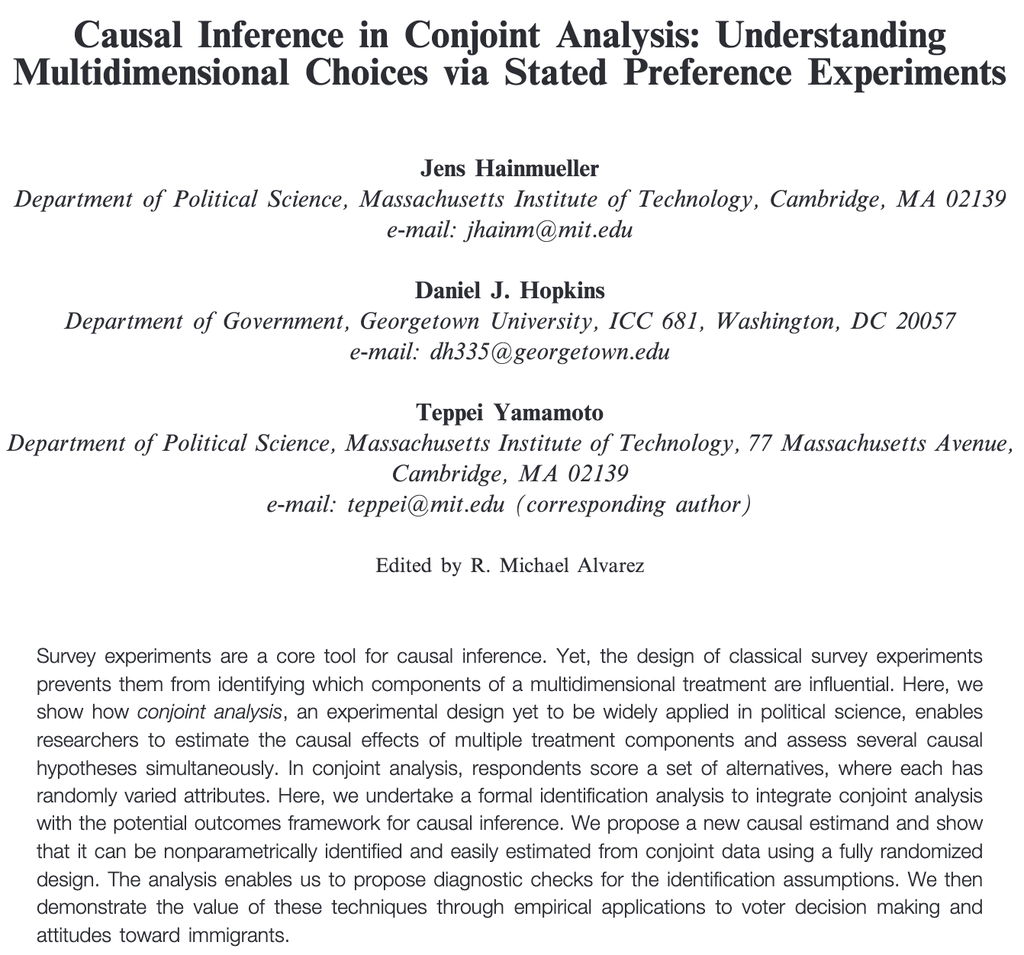

Source Hainmueller et al (2014)

## Example: Immigration applicants (US)

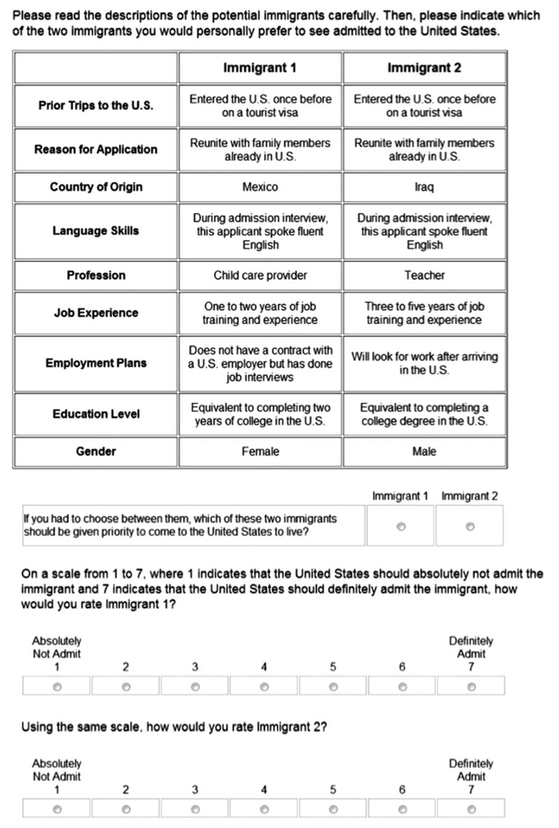

## Example: Immigration applicants (US)

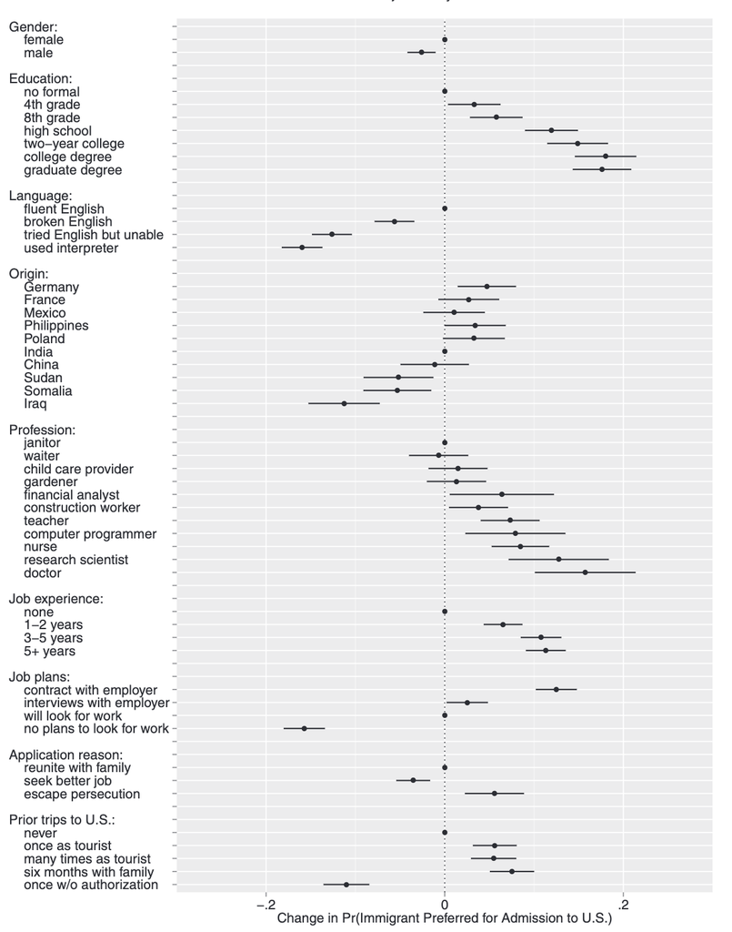

## Example: Presidential candidates (US)

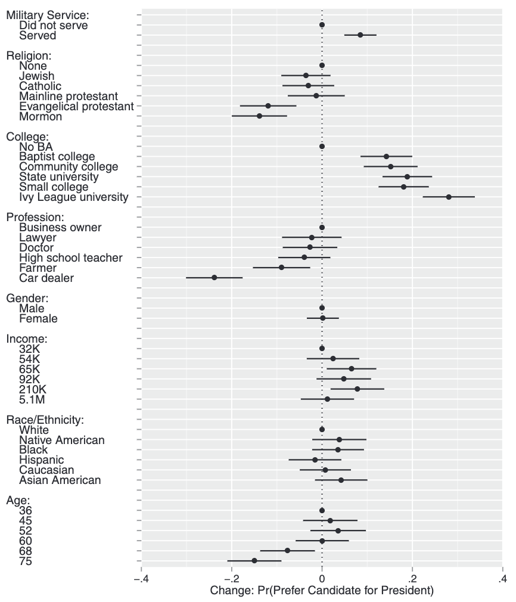

# Conclusion

## Conclusion

- How cool are these methods?! 🤓
- There are many other methods to study sensitive topics
- Today we saw four of them:
  - List experiments
  - Endorsement experiments
  - Randomised response techniques
  - Conjoint analysis
- Please remember that these methods are not perfect, and that they have several assumptions
- They are also areas of active research, so please be mindful that something new may come up 😉
- If you are interested in learning more about these methods, please check the following `R` packages:
- [`list`](https://cran.r-project.org/web/packages/list/index.html)
- [`endorse`](https://cran.r-project.org/web/packages/endorse/index.html)
- [`rr`](https://cran.r-project.org/web/packages/rr/index.html)
- [`cregg`](https://github.com/leeper/cregg)
- Visit the website http://sensitivequestions.org/ for more information
- And let me know if you’d like to learn more about this topic! 🤓

# …And that’s all for today! 🎉

# Thank you for your attention! 🙏